# Hw 3

## Problem 5

Clear all the previous environment and add in the new data

```r
rm(list = ls(all=TRUE))
data = read.csv("7.7.csv")
names(data)[c(3,5)] = c("food.inflation", "Gas.inflation")
attach(data)
```

Create a time series objects out of all the variables and find the ACF and PACF for all of them

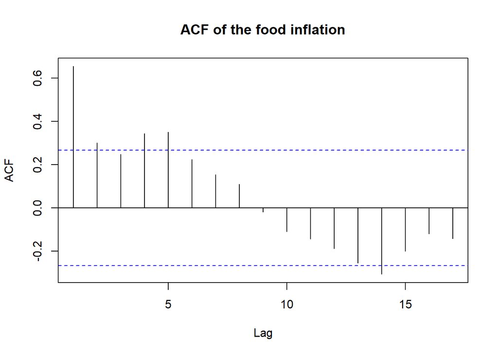

```r
finf_ts = ts(food.inflation, start = 1957, freq = 1)
finf_ts = finf_ts [complete.cases(finf_ts )]

ginf_ts = ts(Gas.inflation, start = 1957, freq = 1)
ginf_ts = ginf_ts [complete.cases(ginf_ts)]

acf(finf_ts, main = "ACF of the food inflation")
```

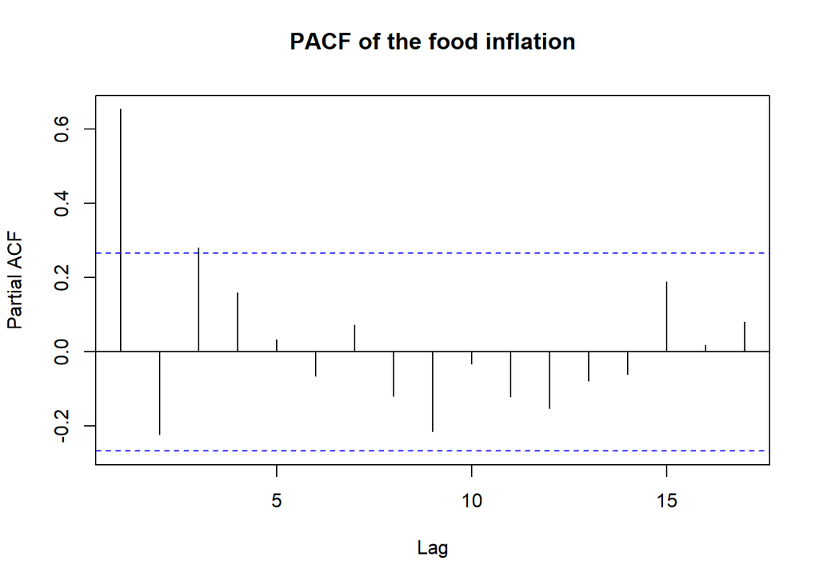

```r
pacf(finf_ts, main = "PACF of the food inflation")
```

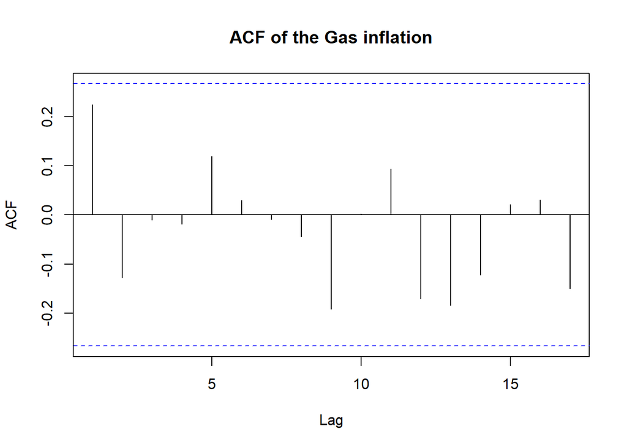

```r
acf(ginf_ts, main = "ACF of the Gas inflation")
```

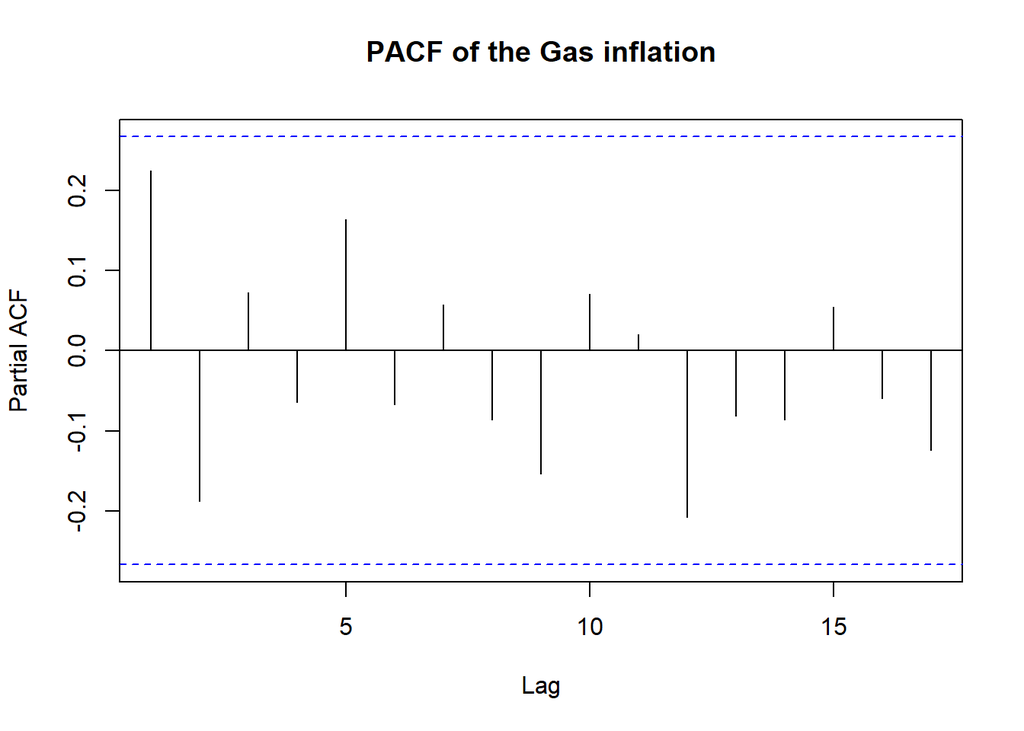

```r
pacf(ginf_ts, main = "PACF of the Gas inflation")
```

Looking at the PACF of all the time series objects, for food inflation, we might fit an AR(3) model; for the gas inflation however, since the ACF and PACF resembles those of a white noise, we need to do a 3-day moving average and look at the ACF and PACF again. After that, we’ll check the ACF and the PACF of the residuals to see if there are any other structure in the data that we have not taken care of.

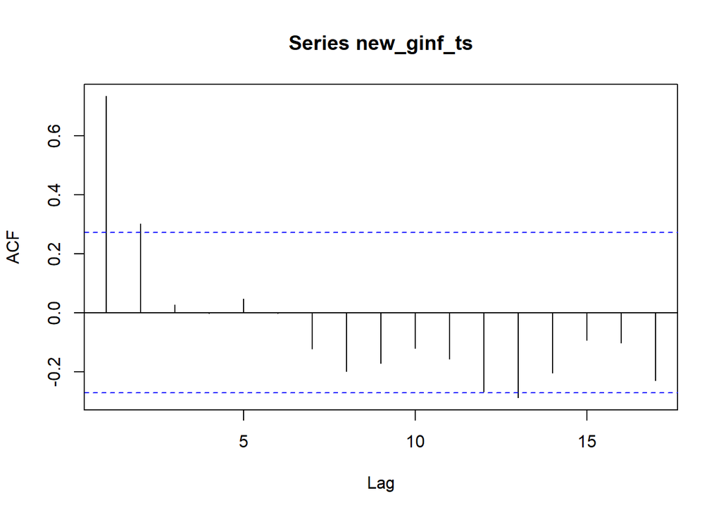

```r
new_ginf_ts = rollmean(ginf_ts, 3)
acf(new_ginf_ts)
```

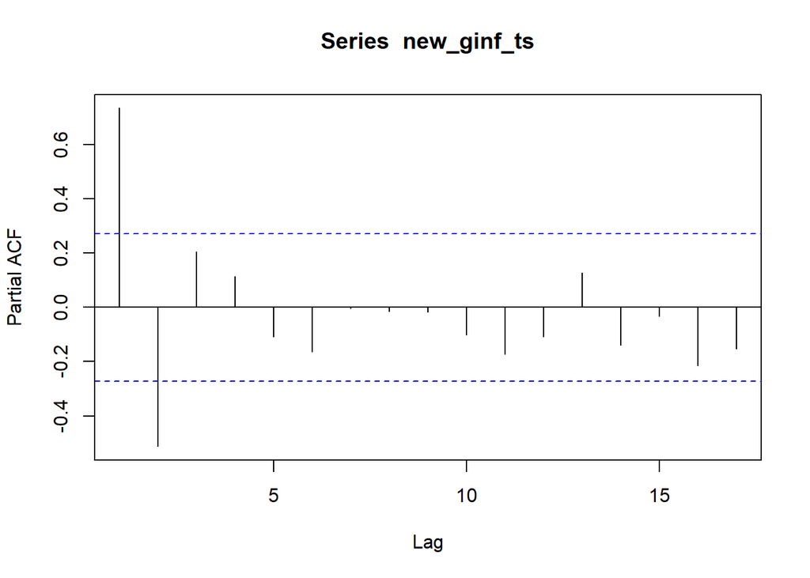

```r
pacf(new_ginf_ts)
```

Since there’s no more dynamics to look for, we do the fitting of model and check again the ACF and PACF of the residuals.

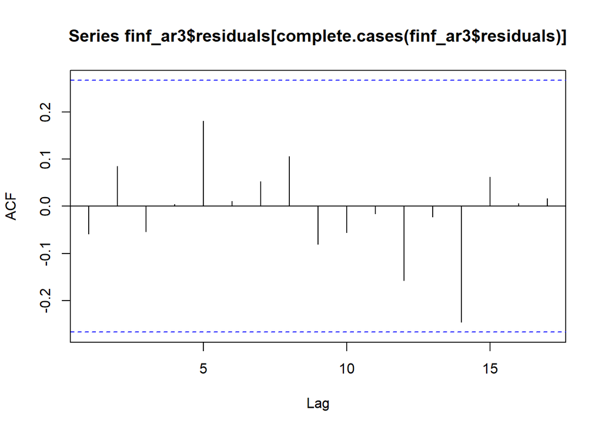

```r
finf_ar3 = Arima(finf_ts, order = c(3,0,0), method = "ML")

ginf_ar2 = Arima(new_ginf_ts, order = c(2,0,0), method = "ML")


acf(finf_ar3$residuals[complete.cases(finf_ar3$residuals)])
```

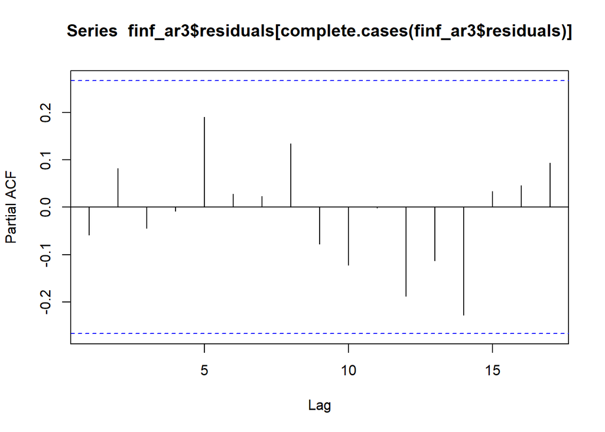

```r
pacf(finf_ar3$residuals[complete.cases(finf_ar3$residuals)])
```

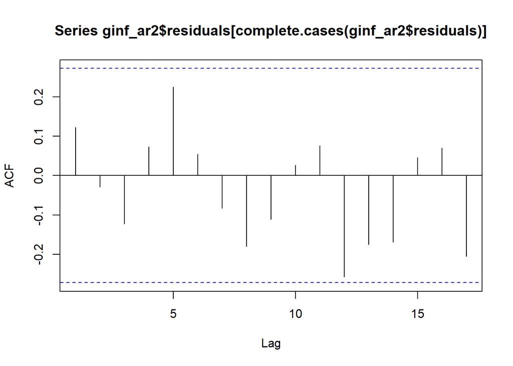

```r
acf(ginf_ar2 $residuals[complete.cases(ginf_ar2$residuals)])
```

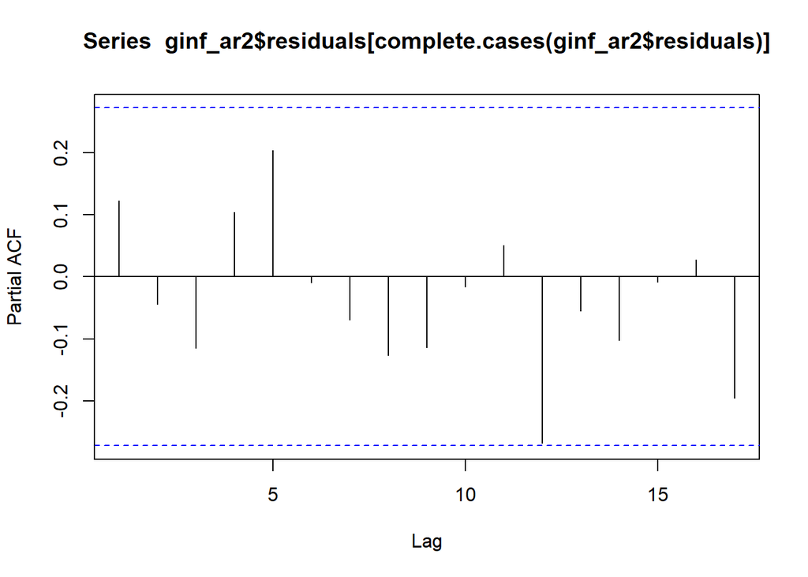

```r
pacf(ginf_ar2 $residuals[complete.cases(ginf_ar2$residuals)])
```

Now we see that the dynamics has been taken care of. So now we’ll conduct a 1-step, 2-step and 3-step forecasts for all the models and its corresponding forecast error and uncertainty.

```r
#last element index
ind = length(food.CPI)

#last element for the CPIs and the inflations
lastelfInf = food.inflation[ind]
lastelgInf = Gas.inflation[ind]

#for food inflation, create a list of realized future values
e = rnorm(3)
finf = vector()
finf[1] = food.inflation[length(food.inflation)-2]
finf[2] = food.inflation[length(food.inflation)-1]
finf[3] = food.inflation[length(food.inflation)]
finf[4] = finf_ar3$coef[4] + finf_ar3$coef[1]*finf[3] + finf_ar3$coef[2]*finf[2] +finf_ar3$coef[3]*finf[1] + e[1]
finf[5] = finf_ar3$coef[4] + finf_ar3$coef[1]*finf[4] + finf_ar3$coef[2]*finf[3] +finf_ar3$coef[3]*finf[2] + e[2]
finf[6] = finf_ar3$coef[4] + finf_ar3$coef[1]*finf[5] + finf_ar3$coef[2]*finf[4] +finf_ar3$coef[3]*finf[3] + e[3]

finf_ar3.pred = forecast(finf_ar3,h=3)
print("For food inflation AR(3,0),")
```

```
## [1] "For food inflation AR(3,0),"
```

```r
for (i in 1:3){
  print(paste("Point forecast for", toString(i), "step(s) is", toString(finf_ar3.pred$mean[i])))
  print(paste("Forecast error for", toString(i), "step(s) is", toString(finf[3+i] -finf_ar3.pred$mean[i])))

  #Since the upper bound of 95% confidence interval = point_forecast + 1.96(forecast_variance)
  forecast_variance = (finf_ar3.pred$upper[i,2] - finf_ar3.pred$mean[i])/1.96
  print(paste("Forecast uncertainty for", toString(i), "step(s) is", toString(forecast_variance)))
  cat("\n")
}
```

```
## [1] "Point forecast for 1 step(s) is 4.78608872619595"
## [1] "Forecast error for 1 step(s) is 2.07220123450175"
## [1] "Forecast uncertainty for 1 step(s) is 2.25500133527757"
##
## [1] "Point forecast for 2 step(s) is 3.75842087256037"
## [1] "Forecast error for 2 step(s) is 5.28904718800229"
## [1] "Forecast uncertainty for 2 step(s) is 3.04082654924731"
##
## [1] "Point forecast for 3 step(s) is 3.25428232526141"
## [1] "Forecast error for 3 step(s) is 5.57415395593766"
## [1] "Forecast uncertainty for 3 step(s) is 3.10184388210994"
```

```r
#do similarly as the above
ginf = vector()
ginf[1] = Gas.inflation[length(Gas.inflation)-1]
ginf[2] = Gas.inflation[length(Gas.inflation)]
ginf[3] = ginf_ar2$coef[3] + ginf_ar2$coef[1]*ginf[2] + ginf_ar2$coef[2]*ginf[1] + e[1]
ginf[4] = ginf_ar2$coef[3] + ginf_ar2$coef[1]*ginf[3] + ginf_ar2$coef[2]*ginf[2] + e[2]
ginf[5] = ginf_ar2$coef[3] + ginf_ar2$coef[1]*ginf[4] + ginf_ar2$coef[2]*ginf[3]+ e[3]
ginf_ar2.pred = forecast(ginf_ar2,h=3)
print("For gas inflation AR(1,0),")
```

```
## [1] "For gas inflation AR(1,0),"
```

```r
for (i in 1:3){
  print(paste("Point forecast for", toString(i), "step(s) is", toString(ginf_ar2.pred$mean[i])))
  print(paste("Forecast error for", toString(i), "step(s) is", toString(ginf[2+i] -ginf_ar2.pred$mean[i])))

  #Since the upper bound of 95% confidence interval = point_forecast + 1.96(forecast_variance)
  forecast_variance = (ginf_ar2.pred$upper[i,2] - ginf_ar2.pred$mean[i])/1.96
  print(paste("Forecast uncertainty for", toString(i), "step(s) is", toString(forecast_variance)))
  cat("\n")
}
```

```
## [1] "Point forecast for 1 step(s) is 7.28102102288834"
## [1] "Forecast error for 1 step(s) is 17.2289373812233"
## [1] "Forecast uncertainty for 1 step(s) is 4.61130565598962"
##
## [1] "Point forecast for 2 step(s) is 7.23441839148651"
## [1] "Forecast error for 2 step(s) is 12.4310654930953"
## [1] "Forecast uncertainty for 2 step(s) is 6.85343091702771"
##
## [1] "Point forecast for 3 step(s) is 6.44977152649723"
## [1] "Forecast error for 3 step(s) is 7.3712713461769"
## [1] "Forecast uncertainty for 3 step(s) is 7.58754652042357"
```

We see that gas inflation has the higher uncertainty which means that gas inflation is harder to forecast.